# Mania_Modelling

by_Jasmin_Doenicke

Step 8

This code processes, analyzes, and visualizes risk factors for mania symptom classes using data from Mplus output files.

# STARTER Code

```
## [1] "E:/code"
```

# Risk Factors

## Without covariates - Demographics

### Sex

```r
data<-read.delim('E:/code/MPLUS/risk_predictors/without_covariates/01_sex.out', header=F,skip=880,sep=" ")   # skip rows before reading in data (check in Excel)

sex <- data[c(4, 6, 8), c(5,19,26,33,40,47, 54, 61)]
sex <- sex %>% remove_empty()
colnames(sex)<-c("var",'lower_99','lower_95','lower_90','OR','upper_90','upper_95','upper_99')
sex <-sex %>% mutate(class=c("1","2",'3'))

sex
```

```
##   var lower_99 lower_95 lower_90    OR upper_90 upper_95 upper_99 class
## 4 SEX    0.578    0.618    0.640 0.768    0.921    0.954    1.021     1
## 6 SEX    0.680    0.726    0.751 0.893    1.063    1.099    1.173     2
## 8 SEX    0.860    0.897    0.917 1.027    1.150    1.176    1.227     3
```

### Race

```r
## BLACK
data<-read.delim('E:/code/MPLUS/risk_predictors/without_covariates/02a_race_b.out', header=F,skip=886,sep=" ")   # skip rows before reading in data (check in Excel)

race_b <- data[c(4,6,8), c(5,16, 23,30,37,44,51,58)]
race_b <- race_b %>% remove_empty()
colnames(race_b)<-c("var",'lower_99','lower_95','lower_90','OR','upper_90','upper_95','upper_99')
race_b <- race_b %>% mutate(class=c("1","2",'3'))

## American Indian/ Alaskan
data<-read.delim('E:/code/MPLUS/risk_predictors/without_covariates/02b_race_ai.out', header=F,skip=886,sep=" ")   # skip rows before reading in data (check in Excel)

race_ai <- data[c(4,6,8), c(5,15, 22, 29, 36, 43, 50, 57)]
race_ai <- race_ai %>% remove_empty()
colnames(race_ai)<-c("var",'lower_99','lower_95','lower_90','OR','upper_90','upper_95','upper_99')
race_ai <- race_ai %>% mutate(class=c("1","2",'3'))

## Pacific
data<-read.delim('E:/code/MPLUS/risk_predictors/without_covariates/02c_race_p.out', header=F,skip=886,sep=" ")   # skip rows before reading in data (check in Excel)

race_p <- data[c(4,6,8), c(5,16, 23,30,37,44,51,58)]
race_p <- race_p %>% remove_empty()
colnames(race_p)<-c("var",'lower_99','lower_95','lower_90','OR','upper_90','upper_95','upper_99')
race_p <- race_p %>% mutate(class=c("1","2",'3'))

## Asian
data<-read.delim('E:/code/MPLUS/risk_predictors/without_covariates/02d_race_as.out', header=F,skip=886,sep=" ")   # skip rows before reading in data (check in Excel)

race_as <- data[c(4,6,8), c(5,15, 22,29, 36, 43, 50, 57)]
race_as <- race_as %>% remove_empty()
colnames(race_as)<-c("var",'lower_99','lower_95','lower_90','OR','upper_90','upper_95','upper_99')
race_as <- race_as %>% mutate(class=c("1","2",'3'))

## Other/ Multiple
data<-read.delim('E:/code/MPLUS/risk_predictors/without_covariates/02e_race_o.out', header=F,skip=886,sep=" ")   # skip rows before reading in data (check in Excel)

race_o <- data[c(4,6,8), c(5,16, 23,30,37,44,51,58)]
race_o <- race_o %>% remove_empty()
colnames(race_o)<-c("var",'lower_99','lower_95','lower_90','OR','upper_90','upper_95','upper_99')
race_o <- race_o %>% mutate(class=c("1","2",'3'))

race_ai
```

```
##       var lower_99 lower_95 lower_90    OR upper_90 upper_95 upper_99 class
## 4 RACE_AI    1.099    1.376    1.543 2.807    5.106    5.727    7.165     1
## 6 RACE_AI    1.040    1.307    1.469 2.703    4.973    5.589    7.022     2
## 8 RACE_AI    0.368    0.482    0.553 1.134    2.326    2.669    3.492     3
```

```r
race_o
```

```
##      var lower_99 lower_95 lower_90    OR upper_90 upper_95 upper_99 class
## 4 RACE_O    0.817    0.951    1.027 1.537    2.299    2.484    2.888     1
## 6 RACE_O    1.180    1.288    1.348 1.704    2.154    2.253    2.460     2
## 8 RACE_O    0.846    0.918    0.958 1.195    1.491    1.555    1.689     3
```

```r
race_as
```

```
##       var lower_99 lower_95 lower_90    OR upper_90 upper_95 upper_99 class
## 4 RACE_AS    0.034    0.051    0.063 0.193    0.589    0.729    1.107     1
## 6 RACE_AS    0.192    0.235    0.261 0.449    0.771    0.855    1.047     2
## 8 RACE_AS    0.259    0.316    0.349 0.592    1.003    1.109    1.351     3
```

```r
race_p
```

```
##      var lower_99 lower_95 lower_90    OR upper_90 upper_95 upper_99 class
## 4 RACE_P    0.000    0.000    0.000 0.000    0.000    0.000    0.000     1
## 6 RACE_P    0.546    0.688    0.775 1.438    2.669    3.005    3.788     2
## 8 RACE_P    0.376    0.474    0.534 0.995    1.852    2.086    2.633     3
```

```r
race_b
```

```
##      var lower_99 lower_95 lower_90    OR upper_90 upper_95 upper_99 class
## 4 RACE_B    0.990    1.198    1.320 2.193    3.643    4.015    4.856     1
## 6 RACE_B    1.044    1.148    1.205 1.551    1.997    2.096    2.304     2
## 8 RACE_B    0.797    0.862    0.897 1.106    1.364    1.419    1.535     3
```

### Ethnicity

```r
data<-read.delim('E:/code/MPLUS/risk_predictors/without_covariates/03_ethn.out', header=F,skip=886,sep=" ")   # skip rows before reading in data (check in Excel)

ethn <- data[c(4,6,8), c(5,18, 25,32,39,46,53,60)]
ethn <- ethn %>% remove_empty()
colnames(ethn)<-c("var",'lower_99','lower_95','lower_90','OR','upper_90','upper_95','upper_99')
ethn <- ethn %>% mutate(class=c("1","2",'3'))
```

### Income-to-Needs

```r
data<-read.delim('E:/code/MPLUS/risk_predictors/without_covariates/04_inr.out', header=F,skip=886,sep=" ")   # skip rows before reading in data (check in Excel)

inr <- data[c(4,6,8), c(5,19,26,33,40,47,54,61)]
inr <- inr %>% remove_empty()
colnames(inr)<-c("var",'lower_99','lower_95','lower_90','OR','upper_90','upper_95','upper_99')
inr <- inr %>% mutate(class=c("1","2",'3'))

inr
```

```
##   var lower_99 lower_95 lower_90    OR upper_90 upper_95 upper_99 class
## 4 INR    0.992    0.993    0.993 0.994    0.996    0.996    0.997     1
## 6 INR    0.998    0.998    0.998 0.998    0.999    0.999    0.999     2
## 8 INR    0.999    0.999    0.999 0.999    0.999    1.000    1.000     3
```

## Without covariates - Risk Factors

### Sleep

```r
data<-read.delim('E:/code/MPLUS/risk_predictors/without_covariates/05_sleep.out', header=F,skip=886,sep=" ")   # skip rows before reading in data (check in Excel)

sleep <- data[c(4,6,8), c(5,17,24,31,38,45,52,59)]
sleep <- sleep %>% remove_empty()
colnames(sleep)<-c("var",'lower_99','lower_95','lower_90','OR','upper_90','upper_95','upper_99')
sleep <- sleep %>% mutate(class=c("1","2",'3'))

sleep
```

```
##     var lower_99 lower_95 lower_90    OR upper_90 upper_95 upper_99 class
## 4 SLEEP    1.247    1.255    1.258 1.278    1.298    1.302    1.309     1
## 6 SLEEP    1.174    1.179    1.182 1.195    1.209    1.211    1.217     2
## 8 SLEEP    1.104    1.112    1.116 1.136    1.157    1.161    1.168     3
```

### IBS

```r
data<-read.delim('E:/code/MPLUS/risk_predictors/without_covariates/06_ibs.out', header=F,skip=886,sep=" ")   # skip rows before reading in data (check in Excel)

ibs <- data[c(4,6,8), c(5,19,26,33,40,47,54,61)]
ibs <- ibs %>% remove_empty()
colnames(ibs)<-c("var",'lower_99','lower_95','lower_90','OR','upper_90','upper_95','upper_99')
ibs <- ibs %>% mutate(class=c("1","2",'3'))

ibs
```

```
##   var lower_99 lower_95 lower_90    OR upper_90 upper_95 upper_99 class
## 4 IBS    1.849    1.926    1.966 2.192    2.443    2.494    2.598     1
## 6 IBS    1.521    1.564    1.586 1.708    1.839    1.866    1.918     2
## 8 IBS    1.188    1.234    1.258 1.392    1.539    1.569    1.630     3
```

#### Asthma

```r
data<-read.delim('E:/code/MPLUS/risk_predictors/without_covariates/07_asthma.out', header=F,skip=881,sep=" ")   # skip rows before reading in data (check in Excel)

asthma <- data[c(4,6,8), c(5,16, 23,30,37,44,51,58)]
asthma <- asthma %>% remove_empty()
colnames(asthma)<-c("var",'lower_99','lower_95','lower_90','OR','upper_90','upper_95','upper_99')
asthma <- asthma %>% mutate(class=c("1","2",'3'))

asthma
```

```
##      var lower_99 lower_95 lower_90    OR upper_90 upper_95 upper_99 class
## 4 ASTHMA    1.230    1.362    1.435 1.884    2.475    2.607    2.888     1
## 6 ASTHMA    1.271    1.337    1.372 1.570    1.797    1.844    1.940     2
## 8 ASTHMA    0.892    0.970    1.013 1.270    1.593    1.663    1.810     3
```

### BMI

```r
data<-read.delim('E:/code/MPLUS/risk_predictors/without_covariates/08_bmi.out', header=F,skip=886,sep=" ")   # skip rows before reading in data (check in Excel)

bmi <- data[c(4,6,8), c(5,19,26,33,40,47,54,61)]
bmi <- bmi %>% remove_empty()
colnames(bmi)<-c("var",'lower_99','lower_95','lower_90','OR','upper_90','upper_95','upper_99')
bmi <- bmi %>% mutate(class=c("1","2",'3'))

bmi
```

```
##   var lower_99 lower_95 lower_90    OR upper_90 upper_95 upper_99 class
## 4 BMI    1.012    1.021    1.026 1.050    1.075    1.079    1.089     1
## 6 BMI    1.023    1.028    1.030 1.042    1.055    1.057    1.062     2
## 8 BMI    0.998    1.005    1.009 1.030    1.051    1.055    1.063     3
```

### All Pregnancy

#### Pregnancy Complications

```r
data<-read.delim('E:/code/MPLUS/risk_predictors/without_covariates/09_preg.out', header=F,skip=881,sep=" ")   # skip rows before reading in data (check in Excel)

preg <- data[c(4,6,8), c(5,18, 25,32,39,46,53,60)]
preg <- preg %>% remove_empty()
colnames(preg)<-c("var",'lower_99','lower_95','lower_90','OR','upper_90','upper_95','upper_99')
preg <- preg %>% mutate(class=c("1","2",'3'))

preg
```

```
##    var lower_99 lower_95 lower_90    OR upper_90 upper_95 upper_99 class
## 4 PREG    1.606    1.703    1.755 2.055    2.405    2.479    2.629     1
## 6 PREG    1.282    1.347    1.382 1.576    1.798    1.844    1.937     2
## 8 PREG    1.185    1.240    1.269 1.433    1.617    1.655    1.732     3
```

#### Obstetric Complications

```r
data<-read.delim('E:/code/MPLUS/risk_predictors/without_covariates/10_obst.out', header=F,skip=881,sep=" ")   # skip rows before reading in data (check in Excel)

obst <- data[c(4,6,8), c(5,18, 25,32,39,46,53,60)]
obst <- obst %>% remove_empty()
colnames(obst)<-c("var",'lower_99','lower_95','lower_90','OR','upper_90','upper_95','upper_99')
obst <- obst %>% mutate(class=c("1","2",'3'))

obst
```

```
##    var lower_99 lower_95 lower_90    OR upper_90 upper_95 upper_99 class
## 4 OBST    0.954    1.061    1.121 1.490    1.980    2.091    2.326     1
## 6 OBST    0.860    0.931    0.969 1.198    1.480    1.541    1.668     2
## 8 OBST    0.992    1.067    1.107 1.346    1.636    1.698    1.827     3
```

#### Premature birth

```r
data<-read.delim('E:/code/MPLUS/risk_predictors/without_covariates/11_premat.out', header=F,skip=886,sep=" ")   # skip rows before reading in data (check in Excel)

premat <- data[c(4,6,8), c(5,16, 23,30,37,44,51,58)]
premat <- premat %>% remove_empty()
colnames(premat)<-c("var",'lower_99','lower_95','lower_90','OR','upper_90','upper_95','upper_99')
premat <- premat %>% mutate(class=c("1","2",'3'))
```

#### Small at Birth (under 2,5kg)

```r
data<-read.delim('E:/code/MPLUS/risk_predictors/without_covariates/12_small.out', header=F,skip=886,sep=" ")   # skip rows before reading in data (check in Excel)

small <- data[c(4,6,8), c(5,17,24,31,38,45,52,59)]
small <- small %>% remove_empty()
colnames(small)<-c("var",'lower_99','lower_95','lower_90','OR','upper_90','upper_95','upper_99')
small <- small %>% mutate(class=c("1","2",'3'))

small
```

```
##     var lower_99 lower_95 lower_90    OR upper_90 upper_95 upper_99 class
## 4 SMALL    0.382    0.451    0.491 0.763    1.186    1.291    1.523     1
## 6 SMALL    0.434    0.489    0.519 0.713    0.978    1.040    1.171     2
## 8 SMALL    0.530    0.586    0.617 0.808    1.057    1.113    1.231     3
```

#### C-Section

```r
data<-read.delim('E:/code/MPLUS/risk_predictors/without_covariates/13_csect.out', header=F,skip=886,sep=" ")   # skip rows before reading in data (check in Excel)

csect <- data[c(4,6,8), c(5,17,24,31,38,45,52,59)]
csect <- csect %>% remove_empty()
colnames(csect)<-c("var",'lower_99','lower_95','lower_90','OR','upper_90','upper_95','upper_99')
csect <- csect %>% mutate(class=c("1","2",'3'))

csect
```

```
##     var lower_99 lower_95 lower_90    OR upper_90 upper_95 upper_99 class
## 4 CSECT    0.589    0.657    0.695 0.932    1.250    1.323    1.476     1
## 6 CSECT    0.664    0.715    0.743 0.907    1.107    1.150    1.239     2
## 8 CSECT    0.732    0.775    0.798 0.930    1.083    1.115    1.181     3
```

### Depression

```r
data<-read.delim('E:/code/MPLUS/risk_predictors/without_covariates/14_depress.out', header=F,skip=886,sep=" ")   # skip rows before reading in data (check in Excel)

depress <- data[c(4,6,8), c(5,15, 22,29,36,43,50,57)]
depress <- depress %>% remove_empty()
colnames(depress)<-c("var",'lower_99','lower_95','lower_90','OR','upper_90','upper_95','upper_99')
depress <- depress %>% mutate(class=c("1","2",'3'))

depress
```

```
##       var lower_99 lower_95 lower_90    OR upper_90 upper_95 upper_99 class
## 4 DEPRESS    2.935    3.022    3.068 3.317    3.587    3.642    3.750     1
## 6 DEPRESS    2.304    2.361    2.390 2.551    2.722    2.756    2.823     2
## 8 DEPRESS    1.753    1.805    1.833 1.983    2.145    2.178    2.243     3
```

### Anxiety

```r
data<-read.delim('E:/code/MPLUS/risk_predictors/without_covariates/15_anx.out', header=F,skip=886,sep=" ")   # skip rows before reading in data (check in Excel)

anx <- data[c(4,6,8), c(5,19,26,33,40,47,54,61)]
anx <- anx %>% remove_empty()
colnames(anx)<-c("var",'lower_99','lower_95','lower_90','OR','upper_90','upper_95','upper_99')
anx <- anx %>% mutate(class=c("1","2",'3'))

anx
```

```
##   var lower_99 lower_95 lower_90    OR upper_90 upper_95 upper_99 class
## 4 ANX    1.942    1.977    1.995 2.092    2.194    2.214    2.254     1
## 6 ANX    1.630    1.653    1.665 1.729    1.796    1.809    1.835     2
## 8 ANX    1.332    1.351    1.361 1.414    1.469    1.480    1.501     3
```

### ADHD

```r
data<-read.delim('E:/code/MPLUS/risk_predictors/without_covariates/16_adhd.out', header=F,skip=886,sep=" ")   # skip rows before reading in data (check in Excel)

adhd <- data[c(4,6,8), c(5,18, 25,32,39,46,53,60)]
adhd <- adhd %>% remove_empty()
colnames(adhd)<-c("var",'lower_99','lower_95','lower_90','OR','upper_90','upper_95','upper_99')
adhd <- adhd %>% mutate(class=c("1","2",'3'))

adhd
```

```
##    var lower_99 lower_95 lower_90    OR upper_90 upper_95 upper_99 class
## 4 ADHD    2.312    2.352    2.373 2.484    2.600    2.623    2.669     1
## 6 ADHD    1.773    1.800    1.814 1.889    1.967    1.982    2.012     2
## 8 ADHD    1.429    1.451    1.462 1.523    1.587    1.599    1.624     3
```

### Oppositional Defiant Disorder

```r
data<-read.delim('E:/code/MPLUS/risk_predictors/without_covariates/17_opposit.out', header=F,skip=886,sep=" ")   # skip rows before reading in data (check in Excel)

opposit <- data[c(4,6,8), c(5,15, 22,29,36,43,50,57)]
opposit <- opposit %>% remove_empty()
colnames(opposit)<-c("var",'lower_99','lower_95','lower_90','OR','upper_90','upper_95','upper_99')
opposit <- opposit %>% mutate(class=c("1","2",'3'))

opposit
```

```
##       var lower_99 lower_95 lower_90    OR upper_90 upper_95 upper_99 class
## 4 OPPOSIT    2.581    2.647    2.681 2.868    3.068    3.108    3.187     1
## 6 OPPOSIT    1.955    1.980    1.993 2.061    2.132    2.146    2.173     2
## 8 OPPOSIT    1.484    1.509    1.523 1.595    1.670    1.685    1.714     3
```

### Conduct Disorder

```r
data<-read.delim('E:/code/MPLUS/risk_predictors/without_covariates/18_conduct.out', header=F,skip=886,sep=" ")   # skip rows before reading in data (check in Excel)

conduct <- data[c(4,6,8), c(5,15, 22,29,36,43,50,57)]
conduct <- conduct %>% remove_empty()
colnames(conduct)<-c("var",'lower_99','lower_95','lower_90','OR','upper_90','upper_95','upper_99')
conduct <- conduct %>% mutate(class=c("1","2",'3'))

conduct
```

```
##       var lower_99 lower_95 lower_90    OR upper_90 upper_95 upper_99 class
## 4 CONDUCT    2.433    2.500    2.535 2.727    2.932    2.973    3.055     1
## 6 CONDUCT    1.968    2.019    2.046 2.193    2.350    2.381    2.444     2
## 8 CONDUCT    1.599    1.649    1.675 1.816    1.970    2.001    2.063     3
```

### Stress

```r
data<-read.delim('E:/code/MPLUS/risk_predictors/without_covariates/19_stress.out', header=F,skip=886,sep=" ")   # skip rows before reading in data (check in Excel)

stress <- data[c(4,6,8), c(5,16, 23,30,37,44,51,58)]
stress <- stress %>% remove_empty()
colnames(stress)<-c("var",'lower_99','lower_95','lower_90','OR','upper_90','upper_95','upper_99')
stress <- stress %>% mutate(class=c("1","2",'3'))

stress
```

```
##      var lower_99 lower_95 lower_90    OR upper_90 upper_95 upper_99 class
## 4 STRESS    2.554    2.617    2.650 2.829    3.019    3.057    3.132     1
## 6 STRESS    2.105    2.135    2.151 2.236    2.324    2.342    2.376     2
## 8 STRESS    1.614    1.641    1.656 1.732    1.813    1.828    1.860     3
```

### Verbal Memory

```r
data<-read.delim('E:/code/MPLUS/risk_predictors/without_covariates/20_ravlt.out', header=F,skip=886,sep=" ")   # skip rows before reading in data (check in Excel)

ravlt <- data[c(4,6,8), c(5,17,24,31,38,45,52,59)]
ravlt <- ravlt %>% remove_empty()
colnames(ravlt)<-c("var",'lower_99','lower_95','lower_90','OR','upper_90','upper_95','upper_99')
ravlt <- ravlt %>% mutate(class=c("1","2",'3'))

ravlt
```

```
##     var lower_99 lower_95 lower_90    OR upper_90 upper_95 upper_99 class
## 4 RAVLT    0.945    0.948    0.950 0.959    0.967    0.969    0.972     1
## 6 RAVLT    0.954    0.957    0.959 0.967    0.975    0.977    0.980     2
## 8 RAVLT    0.986    0.989    0.990 0.998    1.007    1.008    1.011     3
```

### Family Conflict - Parent

```r
data<-read.delim('E:/code/MPLUS/risk_predictors/without_covariates/21_fes_p.out', header=F,skip=886,sep=" ")   # skip rows before reading in data (check in Excel)

fes_p <- data[c(4,6,8), c(5,17,24,31,38,45,52,59)]
fes_p <- fes_p %>% remove_empty()
colnames(fes_p)<-c("var",'lower_99','lower_95','lower_90','OR','upper_90','upper_95','upper_99')
fes_p <- fes_p %>% mutate(class=c("1","2",'3'))

fes_p
```

```
##     var lower_99 lower_95 lower_90    OR upper_90 upper_95 upper_99 class
## 4 FES_P    1.409    1.431    1.443 1.506    1.572    1.585    1.611     1
## 6 FES_P    1.245    1.263    1.273 1.324    1.378    1.388    1.409     2
## 8 FES_P    1.139    1.153    1.159 1.196    1.233    1.241    1.255     3
```

### Family Conflict - Youth

```r
data<-read.delim('E:/code/MPLUS/risk_predictors/without_covariates/22_fes_y.out', header=F,skip=886,sep=" ")   # skip rows before reading in data (check in Excel)

fes_y <- data[c(4,6,8), c(5,17,24,31,38,45,52,59)]
fes_y <- fes_y %>% remove_empty()
colnames(fes_y)<-c("var",'lower_99','lower_95','lower_90','OR','upper_90','upper_95','upper_99')
fes_y <- fes_y %>% mutate(class=c("1","2",'3'))

fes_y
```

```
##     var lower_99 lower_95 lower_90    OR upper_90 upper_95 upper_99 class
## 4 FES_Y    1.131    1.156    1.170 1.243    1.320    1.336    1.366     1
## 6 FES_Y    1.105    1.121    1.129 1.172    1.217    1.226    1.243     2
## 8 FES_Y    0.974    0.989    0.997 1.038    1.080    1.088    1.105     3
```

### Trauma

```r
data<-read.delim('E:/code/MPLUS/risk_predictors/without_covariates/23_trauma.out', header=F,skip=886,sep=" ")   # skip rows before reading in data (check in Excel)

trauma <- data[c(4,6,8), c(5,16, 23,30,37,44,51,58)]
trauma <- trauma %>% remove_empty()
colnames(trauma)<-c("var",'lower_99','lower_95','lower_90','OR','upper_90','upper_95','upper_99')
trauma <- trauma %>% mutate(class=c("1","2",'3'))

trauma
```

```
##      var lower_99 lower_95 lower_90    OR upper_90 upper_95 upper_99 class
## 4 TRAUMA    1.784    1.858    1.897 2.114    2.357    2.406    2.506     1
## 6 TRAUMA    1.671    1.740    1.777 1.983    2.212    2.259    2.354     2
## 8 TRAUMA    1.142    1.185    1.208 1.333    1.472    1.500    1.557     3
```

### Maltreatment

```r
data<-read.delim('E:/code/MPLUS/risk_predictors/without_covariates/24_maltr.out', header=F,skip=886,sep=" ")   # skip rows before reading in data (check in Excel)

maltr <- data[c(4,6,8), c(5,17,24,31,38,45,52,59)]
maltr <- maltr %>% remove_empty()
colnames(maltr)<-c("var",'lower_99','lower_95','lower_90','OR','upper_90','upper_95','upper_99')
maltr <- maltr %>% mutate(class=c("1","2",'3'))

maltr
```

```
##     var lower_99 lower_95 lower_90    OR upper_90 upper_95 upper_99 class
## 4 MALTR    1.485    1.606    1.671 2.059    2.537    2.640    2.855     1
## 6 MALTR    1.287    1.382    1.434 1.736    2.103    2.181    2.343     2
## 8 MALTR    0.744    0.858    0.924 1.355    1.987    2.138    2.468     3
```

### First-Degree Relatives

```r
data<-read.delim('E:/code/MPLUS/risk_predictors/without_covariates/25_first_d.out', header=F,skip=881,sep=" ")   # skip rows before reading in data (check in Excel)

first_d <- data[c(4,6,8), c(5,15, 22,29,36,43,50,57)]
first_d <- first_d %>% remove_empty()
colnames(first_d)<-c("var",'lower_99','lower_95','lower_90','OR','upper_90','upper_95','upper_99')
first_d <- first_d %>% mutate(class=c("1","2",'3'))

first_d
```

```
##       var lower_99 lower_95 lower_90    OR upper_90 upper_95 upper_99 class
## 4 FIRST_D    1.810    2.128    2.312 3.560    5.484    5.957    7.002     1
## 6 FIRST_D    1.904    2.123    2.245 3.003    4.017    4.247    4.735     2
## 8 FIRST_D    0.639    0.757    0.826 1.303    2.053    2.240    2.657     3
```

### Merge Riskfactors without Covariates

```r
riskfactors_without_covariates = rbind(sex, race_b, race_ai, race_p, race_as, race_o, ethn, inr, sleep, ibs, asthma, bmi,
preg, obst, premat, small, csect, depress, anx, adhd, opposit, conduct, stress, ravlt, fes_p, fes_y, trauma, maltr, first_d)

#convert OR to effect size
riskfactors_without_covariates <- riskfactors_without_covariates %>% mutate(est_d=oddsratio_to_d(OR),
                      lower_95_d=oddsratio_to_d(lower_95),
                      upper_95_d=oddsratio_to_d(upper_95))

# add explanation to group:
riskfactors_without_covariates$meaning <- ifelse(riskfactors_without_covariates$class == 1, "High Symptoms VS. No Symptoms",
               ifelse(riskfactors_without_covariates$class == 2, "Moderate Symptoms VS. No Symptoms",
               ifelse(riskfactors_without_covariates$class == 3, "Low Symptoms VS. No Symptoms", NA)))

riskfactors_without_covariates_FINAL = riskfactors_without_covariates

#save
#save(riskfactors_without_covariates_FINAL,file="E:/data/riskfactors_without_covariates_FINAL.rdata")

riskfactors_without_covariates_FINAL
```

```
##         var lower_99 lower_95 lower_90    OR upper_90 upper_95 upper_99 class
## 4       SEX    0.578    0.618    0.640 0.768    0.921    0.954    1.021     1
## 6       SEX     0.68    0.726    0.751 0.893    1.063    1.099    1.173     2
## 8       SEX     0.86    0.897    0.917 1.027    1.150    1.176    1.227     3
## 41   RACE_B     0.99    1.198    1.320 2.193    3.643    4.015    4.856     1
## 61   RACE_B    1.044    1.148    1.205 1.551    1.997    2.096    2.304     2
## 81   RACE_B    0.797    0.862    0.897 1.106    1.364    1.419    1.535     3
## 42  RACE_AI    1.099    1.376    1.543 2.807    5.106    5.727    7.165     1
## 62  RACE_AI     1.04    1.307    1.469 2.703    4.973    5.589    7.022     2
## 82  RACE_AI    0.368    0.482    0.553 1.134    2.326    2.669    3.492     3
## 43   RACE_P    0.000    0.000    0.000 0.000    0.000    0.000    0.000     1
## 63   RACE_P    0.546    0.688    0.775 1.438    2.669    3.005    3.788     2
## 83   RACE_P    0.376    0.474    0.534 0.995    1.852    2.086    2.633     3
## 44  RACE_AS    0.034    0.051    0.063 0.193    0.589    0.729    1.107     1
## 64  RACE_AS    0.192    0.235    0.261 0.449    0.771    0.855    1.047     2
```

[output cut: 161 more lines]

### Merge Demographics

```r
demographics_without_covariates = rbind(sex, race_b, race_ai, race_p, race_as, race_o, ethn, inr)

#convert OR to effect size
demographics_without_covariates <- demographics_without_covariates %>% mutate(est_d=oddsratio_to_d(OR),
                      lower_95_d=oddsratio_to_d(lower_95),
                      upper_95_d=oddsratio_to_d(upper_95))

# add explanation to group:
demographics_without_covariates$meaning <- ifelse(demographics_without_covariates$class == 1, "High Symptoms VS. No Symptoms",
               ifelse(demographics_without_covariates$class == 2, "Moderate Symptoms VS. No Symptoms",
               ifelse(demographics_without_covariates$class == 3, "Low Symptoms VS. No Symptoms", NA)))

demographics_without_covariates_FINAL = demographics_without_covariates

#save
#save(demographics_without_covariates_FINAL,file="E:/data/demographics_without_covariates_FINAL.rdata")

demographics_without_covariates_FINAL
```

```
##        var lower_99 lower_95 lower_90    OR upper_90 upper_95 upper_99 class
## 4      SEX    0.578    0.618    0.640 0.768    0.921    0.954    1.021     1
## 6      SEX     0.68    0.726    0.751 0.893    1.063    1.099    1.173     2
## 8      SEX     0.86    0.897    0.917 1.027    1.150    1.176    1.227     3
## 41  RACE_B     0.99    1.198    1.320 2.193    3.643    4.015    4.856     1
## 61  RACE_B    1.044    1.148    1.205 1.551    1.997    2.096    2.304     2
## 81  RACE_B    0.797    0.862    0.897 1.106    1.364    1.419    1.535     3
## 42 RACE_AI    1.099    1.376    1.543 2.807    5.106    5.727    7.165     1
## 62 RACE_AI     1.04    1.307    1.469 2.703    4.973    5.589    7.022     2
## 82 RACE_AI    0.368    0.482    0.553 1.134    2.326    2.669    3.492     3
## 43  RACE_P    0.000    0.000    0.000 0.000    0.000    0.000    0.000     1
## 63  RACE_P    0.546    0.688    0.775 1.438    2.669    3.005    3.788     2
## 83  RACE_P    0.376    0.474    0.534 0.995    1.852    2.086    2.633     3
## 44 RACE_AS    0.034    0.051    0.063 0.193    0.589    0.729    1.107     1
## 64 RACE_AS    0.192    0.235    0.261 0.449    0.771    0.855    1.047     2
```

[output cut: 35 more lines]

## With covariates

### Sleep

```r
data<-read.delim('E:/code/MPLUS/risk_predictors/with_covariates/01_sleep.out', header=F,skip=1211,sep=" ")   # skip rows before reading in data (check in Excel)

sleep <- data[c(4,15,26), c(5,17,24,31,38,45,52,59)]
sleep <- sleep %>% remove_empty()
colnames(sleep)<-c("var",'lower_99','lower_95','lower_90','OR','upper_90','upper_95','upper_99')
sleep <- sleep %>% mutate(class=c("1","2",'3'))

sleep
```

```
##      var lower_99 lower_95 lower_90    OR upper_90 upper_95 upper_99 class
## 4  SLEEP    1.263    1.272    1.277 1.300    1.324    1.328    1.338     1
## 15 SLEEP    1.189    1.194    1.197 1.212    1.227    1.229    1.235     2
## 26 SLEEP    1.116    1.123    1.127 1.146    1.165    1.169    1.176     3
```

### IBS

```r
data<-read.delim('E:/code/MPLUS/risk_predictors/with_covariates/02_ibs.out', header=F,skip=1211,sep=" ")   # skip rows before reading in data (check in Excel)

ibs <- data[c(4,15,26), c(5,19,26,33,40,47,54,61)]
ibs <- ibs %>% remove_empty()
colnames(ibs)<-c("var",'lower_99','lower_95','lower_90','OR','upper_90','upper_95','upper_99')
ibs <- ibs %>% mutate(class=c("1","2",'3'))

ibs
```

```
##    var lower_99 lower_95 lower_90    OR upper_90 upper_95 upper_99 class
## 4  IBS    1.759    1.863    1.919 2.238    2.610    2.688    2.848     1
## 15 IBS    1.548    1.593    1.617 1.745    1.884    1.911    1.967     2
## 26 IBS    1.154    1.203    1.229 1.375    1.538    1.571    1.638     3
```

#### Asthma

```r
data<-read.delim('E:/code/MPLUS/risk_predictors/with_covariates/03_asthma.out', header=F,skip=1211,sep=" ")   # skip rows before reading in data (check in Excel)

asthma <- data[c(4,15,26), c(5,16, 23,30,37,44,51,58)]
asthma <- asthma %>% remove_empty()
colnames(asthma)<-c("var",'lower_99','lower_95','lower_90','OR','upper_90','upper_95','upper_99')
asthma <- asthma %>% mutate(class=c("1","2",'3'))

asthma
```

```
##       var lower_99 lower_95 lower_90    OR upper_90 upper_95 upper_99 class
## 4  ASTHMA    1.114    1.238    1.306 1.730    2.290    2.417    2.685     1
## 15 ASTHMA    1.005    1.065    1.097 1.281    1.496    1.541    1.633     2
## 26 ASTHMA    0.777    0.856    0.899 1.164    1.507    1.584    1.744     3
```

### BMI

```r
data<-read.delim('E:/code/MPLUS/risk_predictors/with_covariates/04_bmi.out', header=F,skip=1211,sep=" ")   # skip rows before reading in data (check in Excel)

bmi <- data[c(4,15,26), c(5,19,26,33,40,47,54,61)]
bmi <- bmi %>% remove_empty()
colnames(bmi)<-c("var",'lower_99','lower_95','lower_90','OR','upper_90','upper_95','upper_99')
bmi <- bmi %>% mutate(class=c("1","2",'3'))

bmi
```

```
##    var lower_99 lower_95 lower_90    OR upper_90 upper_95 upper_99 class
## 4  BMI    0.983    0.990    0.994 1.013    1.033    1.037    1.045     1
## 15 BMI    0.983    0.989    0.992 1.009    1.025    1.028    1.034     2
## 26 BMI    0.985    0.994    0.999 1.023    1.048    1.053    1.063     3
```

### All Pregnancy

#### Pregnancy Complications

```r
data<-read.delim('E:/code/MPLUS/risk_predictors/with_covariates/05_preg.out', header=F,skip=1211,sep=" ")   # skip rows before reading in data (check in Excel)

preg <- data[c(4,15,26), c(5,18, 25,32,39,46,53,60)]
preg <- preg %>% remove_empty()
colnames(preg)<-c("var",'lower_99','lower_95','lower_90','OR','upper_90','upper_95','upper_99')
preg <- preg %>% mutate(class=c("1","2",'3'))

preg
```

```
##     var lower_99 lower_95 lower_90    OR upper_90 upper_95 upper_99 class
## 4  PREG    1.424    1.524    1.578 1.891    2.266    2.346    2.510     1
## 15 PREG    1.066    1.124    1.155 1.331    1.533    1.575    1.661     2
## 26 PREG    1.098    1.142    1.166 1.295    1.438    1.468    1.527     3
```

#### Obstetric Complications

```r
data<-read.delim('E:/code/MPLUS/risk_predictors/with_covariates/06_obst.out', header=F,skip=1211,sep=" ")   # skip rows before reading in data (check in Excel)

obst <- data[c(4,15,26), c(5,18, 25,32,39,46,53,60)]
obst <- obst %>% remove_empty()
colnames(obst)<-c("var",'lower_99','lower_95','lower_90','OR','upper_90','upper_95','upper_99')
obst <- obst %>% mutate(class=c("1","2",'3'))

obst
```

```
##     var lower_99 lower_95 lower_90    OR upper_90 upper_95 upper_99 class
## 4  OBST    1.084    1.216    1.290 1.753    2.384    2.528    2.836     1
## 15 OBST    0.838    0.909    0.947 1.177    1.463    1.525    1.655     2
## 26 OBST    1.017    1.090    1.129 1.356    1.629    1.687    1.807     3
```

#### Premature birth

```r
data<-read.delim('E:/code/MPLUS/risk_predictors/with_covariates/07_premat.out', header=F,skip=1211,sep=" ")   # skip rows before reading in data (check in Excel)

premat <- data[c(4,15,26), c(5,16, 23,30,37,44,51,58)]
premat <- premat %>% remove_empty()
colnames(premat)<-c("var",'lower_99','lower_95','lower_90','OR','upper_90','upper_95','upper_99')
premat <- premat %>% mutate(class=c("1","2",'3'))

premat
```

```
##       var lower_99 lower_95 lower_90    OR upper_90 upper_95 upper_99 class
## 4  PREMAT    0.471    0.546    0.588 0.872    1.293    1.395    1.616     1
## 15 PREMAT    0.560    0.604    0.627 0.765    0.934    0.970    1.045     2
## 26 PREMAT    0.528    0.585    0.616 0.807    1.058    1.115    1.233     3
```

#### Small at Birth (under 2,5kg)

```r
data<-read.delim('E:/code/MPLUS/risk_predictors/with_covariates/08_small.out', header=F,skip=1211,sep=" ")   # skip rows before reading in data (check in Excel)

small <- data[c(4,15,26), c(5,17,24,31,38,45,52,59)]
small <- small %>% remove_empty()
colnames(small)<-c("var",'lower_99','lower_95','lower_90','OR','upper_90','upper_95','upper_99')
small <- small %>% mutate(class=c("1","2",'3'))

small
```

```
##      var lower_99 lower_95 lower_90    OR upper_90 upper_95 upper_99 class
## 4  SMALL    0.390    0.457    0.496 0.760    1.164    1.263    1.482     1
## 15 SMALL    0.462    0.513    0.542 0.716    0.946    0.998    1.108     2
## 26 SMALL    0.505    0.553    0.578 0.735    0.934    0.978    1.070     3
```

#### C-Section

```r
data<-read.delim('E:/code/MPLUS/risk_predictors/with_covariates/09_csect.out', header=F,skip=1211,sep=" ")   # skip rows before reading in data (check in Excel)

csect <- data[c(4,15,26), c(5,17,24,31,38,45,52,59)]
csect <- csect %>% remove_empty()
colnames(csect)<-c("var",'lower_99','lower_95','lower_90','OR','upper_90','upper_95','upper_99')
csect <- csect %>% mutate(class=c("1","2",'3'))

csect
```

```
##      var lower_99 lower_95 lower_90    OR upper_90 upper_95 upper_99 class
## 4  CSECT    0.674    0.739    0.774 0.986    1.257    1.317    1.442     1
## 15 CSECT    0.752    0.809    0.840 1.021    1.242    1.289    1.387     2
## 26 CSECT    0.764    0.811    0.836 0.983    1.154    1.190    1.264     3
```

### Depression

```r
data<-read.delim('E:/code/MPLUS/risk_predictors/with_covariates/10_depress.out', header=F,skip=1216,sep=" ")   # skip rows before reading in data (check in Excel)

depress <- data[c(4,15,26), c(5,15, 22,29,36,43,50,57)]
depress <- depress %>% remove_empty()
colnames(depress)<-c("var",'lower_99','lower_95','lower_90','OR','upper_90','upper_95','upper_99')
depress <- depress %>% mutate(class=c("1","2",'3'))

depress
```

```
##        var lower_99 lower_95 lower_90    OR upper_90 upper_95 upper_99 class
## 4  DEPRESS    3.066    3.166    3.219 3.507    3.821    3.885    4.011     1
## 15 DEPRESS    2.287    2.367    2.409 2.641    2.895    2.946    3.049     2
## 26 DEPRESS    1.818    1.867    1.892 2.032    2.182    2.212    2.272     3
```

### Anxiety

```r
data<-read.delim('E:/code/MPLUS/risk_predictors/with_covariates/11_anx.out', header=F,skip=1211,sep=" ")   # skip rows before reading in data (check in Excel)

anx <- data[c(4,15,26), c(5,19,26,33,40,47,54,61)]
anx <- anx %>% remove_empty()
colnames(anx)<-c("var",'lower_99','lower_95','lower_90','OR','upper_90','upper_95','upper_99')
anx <- anx %>% mutate(class=c("1","2",'3'))

anx
```

```
##    var lower_99 lower_95 lower_90    OR upper_90 upper_95 upper_99 class
## 4  ANX    2.011    2.061    2.087 2.227    2.377    2.407    2.466     1
## 15 ANX    1.667    1.695    1.710 1.790    1.874    1.890    1.923     2
## 26 ANX    1.349    1.369    1.379 1.433    1.489    1.500    1.521     3
```

### ADHD

```r
data<-read.delim('E:/code/MPLUS/risk_predictors/with_covariates/12_adhd.out', header=F,skip=1211,sep=" ")   # skip rows before reading in data (check in Excel)

adhd <- data[c(4,15,26), c(5,18, 25,32,39,46,53,60)]
adhd <- adhd %>% remove_empty()
colnames(adhd)<-c("var",'lower_99','lower_95','lower_90','OR','upper_90','upper_95','upper_99')
adhd <- adhd %>% mutate(class=c("1","2",'3'))

adhd
```

```
##     var lower_99 lower_95 lower_90    OR upper_90 upper_95 upper_99 class
## 4  ADHD    2.434    2.481    2.506 2.638    2.777    2.805    2.860     1
## 15 ADHD    1.824    1.846    1.857 1.918    1.980    1.992    2.016     2
## 26 ADHD    1.410    1.436    1.449 1.521    1.596    1.610    1.640     3
```

### Oppositional Defiant Disorder

```r
data<-read.delim('E:/code/MPLUS/risk_predictors/with_covariates/13_opposit.out', header=F,skip=1215, sep=" ")   # skip rows before reading in data (check in Excel)

opposit <- data[c(4,15,26), c(5,15, 22,29,36,43,50,57)]
opposit <- opposit %>% remove_empty()
colnames(opposit)<-c("var",'lower_99','lower_95','lower_90','OR','upper_90','upper_95','upper_99')
opposit <- opposit %>% mutate(class=c("1","2",'3'))

opposit
```

```
##        var lower_99 lower_95 lower_90    OR upper_90 upper_95 upper_99 class
## 4  OPPOSIT    2.705    2.783    2.823 3.044    3.283    3.331    3.426     1
## 15 OPPOSIT    1.976    2.012    2.030 2.129    2.233    2.254    2.294     2
## 26 OPPOSIT    1.487    1.516    1.532 1.615    1.702    1.719    1.754     3
```

### Conduct Disorder

```r
data<-read.delim('E:/code/MPLUS/risk_predictors/with_covariates/14_conduct.out', header=F,skip=1214,sep=" ")   # skip rows before reading in data (check in Excel)

conduct <- data[c(4,15,26), c(5,15, 22,29,36,43,50,57)]
conduct <- conduct %>% remove_empty()
colnames(conduct)<-c("var",'lower_99','lower_95','lower_90','OR','upper_90','upper_95','upper_99')
conduct <- conduct %>% mutate(class=c("1","2",'3'))

conduct
```

```
##        var lower_99 lower_95 lower_90    OR upper_90 upper_95 upper_99 class
## 4  CONDUCT    2.321    2.389    2.424 2.615    2.822    2.864    2.947     1
## 15 CONDUCT    1.891    1.933    1.955 2.075    2.202    2.228    2.278     2
## 26 CONDUCT    1.575    1.616    1.638 1.756    1.882    1.907    1.957     3
```

### Stress

```r
data<-read.delim('E:/code/MPLUS/risk_predictors/with_covariates/15_stress.out', header=F,skip=1211,sep=" ")   # skip rows before reading in data (check in Excel)

stress <- data[c(4,15,26), c(5,16, 23,30,37,44,51,58)]
stress <- stress %>% remove_empty()
colnames(stress)<-c("var",'lower_99','lower_95','lower_90','OR','upper_90','upper_95','upper_99')
stress <- stress %>% mutate(class=c("1","2",'3'))

stress
```

```
##       var lower_99 lower_95 lower_90    OR upper_90 upper_95 upper_99 class
## 4  STRESS    2.700    2.773    2.810 3.016    3.237    3.281    3.369     1
## 15 STRESS    2.164    2.206    2.227 2.343    2.465    2.489    2.537     2
## 26 STRESS    1.658    1.685    1.699 1.772    1.849    1.864    1.894     3
```

### Verbal Memory

```r
data<-read.delim('E:/code/MPLUS/risk_predictors/with_covariates/16_ravlt.out', header=F,skip=1211,sep=" ")   # skip rows before reading in data (check in Excel)

ravlt <- data[c(4,15,26), c(5,17,24,31,38,45,52,59)]
ravlt <- ravlt %>% remove_empty()
colnames(ravlt)<-c("var",'lower_99','lower_95','lower_90','OR','upper_90','upper_95','upper_99')
ravlt <- ravlt %>% mutate(class=c("1","2",'3'))

ravlt
```

```
##      var lower_99 lower_95 lower_90    OR upper_90 upper_95 upper_99 class
## 4  RAVLT    0.961    0.965    0.967 0.976    0.986    0.988    0.992     1
## 15 RAVLT    0.963    0.967    0.969 0.979    0.990    0.992    0.996     2
## 26 RAVLT    0.989    0.992    0.994 1.002    1.010    1.012    1.015     3
```

### Family Conflict - Parent

```r
data<-read.delim('E:/code/MPLUS/risk_predictors/with_covariates/17_fes_p.out', header=F,skip=1211,sep=" ")   # skip rows before reading in data (check in Excel)

fes_p <- data[c(4,15,26), c(5,17,24,31,38,45,52,59)]
fes_p <- fes_p %>% remove_empty()
colnames(fes_p)<-c("var",'lower_99','lower_95','lower_90','OR','upper_90','upper_95','upper_99')
fes_p <- fes_p %>% mutate(class=c("1","2",'3'))

fes_p
```

```
##      var lower_99 lower_95 lower_90    OR upper_90 upper_95 upper_99 class
## 4  FES_P    1.349    1.378    1.393 1.474    1.560    1.577    1.610     1
## 15 FES_P    1.257    1.275    1.284 1.332    1.382    1.391    1.410     2
## 26 FES_P    1.146    1.158    1.164 1.198    1.232    1.238    1.252     3
```

### Family Conflict - Youth

```r
data<-read.delim('E:/code/MPLUS/risk_predictors/with_covariates/18_fes_y.out', header=F,skip=1211,sep=" ")   # skip rows before reading in data (check in Excel)

fes_y <- data[c(4,15,26), c(5,17,24,31,38,45,52,59)]
fes_y <- fes_y %>% remove_empty()
colnames(fes_y)<-c("var",'lower_99','lower_95','lower_90','OR','upper_90','upper_95','upper_99')
fes_y <- fes_y %>% mutate(class=c("1","2",'3'))

fes_y
```

```
##      var lower_99 lower_95 lower_90    OR upper_90 upper_95 upper_99 class
## 4  FES_Y    1.077    1.093    1.101 1.146    1.192    1.201    1.219     1
## 15 FES_Y    1.094    1.109    1.116 1.155    1.196    1.204    1.220     2
## 26 FES_Y    0.929    0.947    0.956 1.005    1.056    1.066    1.087     3
```

### Trauma

```r
data<-read.delim('E:/code/MPLUS/risk_predictors/with_covariates/19_trauma.out', header=F,skip=1211,sep=" ")   # skip rows before reading in data (check in Excel)

trauma <- data[c(4,15,26), c(5,16, 23,30,37,44,51,58)]
trauma <- trauma %>% remove_empty()
colnames(trauma)<-c("var",'lower_99','lower_95','lower_90','OR','upper_90','upper_95','upper_99')
trauma <- trauma %>% mutate(class=c("1","2",'3'))

trauma
```

```
##       var lower_99 lower_95 lower_90    OR upper_90 upper_95 upper_99 class
## 4  TRAUMA    1.589    1.657    1.693 1.894    2.118    2.164    2.257     1
## 15 TRAUMA    1.537    1.605    1.641 1.842    2.069    2.115    2.209     2
## 26 TRAUMA    1.081    1.129    1.154 1.296    1.455    1.488    1.554     3
```

### Maltreatment

```r
data<-read.delim('E:/code/MPLUS/risk_predictors/with_covariates/20_maltr.out', header=F,skip=1211,sep=" ")   # skip rows before reading in data (check in Excel)

maltr <- data[c(4,15,26), c(5,17,24,31,38,45,52,59)]
maltr <- maltr %>% remove_empty()
colnames(maltr)<-c("var",'lower_99','lower_95','lower_90','OR','upper_90','upper_95','upper_99')
maltr <- maltr %>% mutate(class=c("1","2",'3'))

maltr
```

```
##      var lower_99 lower_95 lower_90    OR upper_90 upper_95 upper_99 class
## 4  MALTR    1.314    1.416    1.471 1.794    2.189    2.274    2.450     1
## 15 MALTR    1.194    1.273    1.315 1.558    1.847    1.908    2.033     2
## 26 MALTR    0.782    0.876    0.928 1.257    1.702    1.804    2.021     3
```

### First-Degree Relatives

```r
data<-read.delim('E:/code/MPLUS/risk_predictors/with_covariates/21_first_d.out', header=F,skip=1214,sep=" ")   # skip rows before reading in data (check in Excel)

first_d <- data[c(4,15,26), c(5,15, 22,29,36,43,50,57)]
first_d <- first_d %>% remove_empty()
colnames(first_d)<-c("var",'lower_99','lower_95','lower_90','OR','upper_90','upper_95','upper_99')
first_d <- first_d %>% mutate(class=c("1","2",'3'))

first_d
```

```
##        var lower_99 lower_95 lower_90    OR upper_90 upper_95 upper_99 class
## 4  FIRST_D    1.536    1.794    1.942 2.937    4.442    4.808    5.614     1
## 15 FIRST_D    1.571    1.766    1.874 2.558    3.493    3.707    4.165     2
## 26 FIRST_D    0.783    0.900    0.966 1.402    2.034    2.185    2.511     3
```

### Merge Riskfactors with Covariates

```r
riskfactors_with_covariates = rbind(sleep, ibs, asthma, bmi, preg, obst, premat, small, csect, depress, anx, adhd, opposit, conduct, stress, ravlt, fes_p, fes_y, trauma, maltr, first_d)

#making everything numeric
riskfactors_with_covariates$lower_99 = as.numeric(riskfactors_with_covariates$lower_99)
riskfactors_with_covariates$lower_95 = as.numeric(riskfactors_with_covariates$lower_95)
riskfactors_with_covariates$lower_90 = as.numeric(riskfactors_with_covariates$lower_90)
riskfactors_with_covariates$class = as.numeric(riskfactors_with_covariates$class)

#convert OR to effect size
riskfactors_with_covariates <- riskfactors_with_covariates %>% mutate(est_d=oddsratio_to_d(OR),
                      lower_95_d=oddsratio_to_d(lower_95),
                      upper_95_d=oddsratio_to_d(upper_95))

# add explanation to group
riskfactors_with_covariates$meaning <- ifelse(riskfactors_with_covariates$class == 1, "High Symptoms VS. No Symptoms",
               ifelse(riskfactors_with_covariates$class == 2, "Moderate Symptoms VS. No Symptoms",
               ifelse(riskfactors_with_covariates$class == 3, "Low Symptoms VS. No Symptoms", NA)))


riskfactors_with_covariates_FINAL = riskfactors_with_covariates

#save
#save(riskfactors_with_covariates_FINAL,file="E:/data/riskfactors_with_covariates_FINAL.rdata")

riskfactors_with_covariates_FINAL
```

```
##          var lower_99 lower_95 lower_90    OR upper_90 upper_95 upper_99 class
## 4      SLEEP    1.263    1.272    1.277 1.300    1.324    1.328    1.338     1
## 15     SLEEP    1.189    1.194    1.197 1.212    1.227    1.229    1.235     2
## 26     SLEEP    1.116    1.123    1.127 1.146    1.165    1.169    1.176     3
## 41       IBS    1.759    1.863    1.919 2.238    2.610    2.688    2.848     1
## 151      IBS    1.548    1.593    1.617 1.745    1.884    1.911    1.967     2
## 261      IBS    1.154    1.203    1.229 1.375    1.538    1.571    1.638     3
## 42    ASTHMA    1.114    1.238    1.306 1.730    2.290    2.417    2.685     1
## 152   ASTHMA    1.005    1.065    1.097 1.281    1.496    1.541    1.633     2
## 262   ASTHMA    0.777    0.856    0.899 1.164    1.507    1.584    1.744     3
## 43       BMI    0.983    0.990    0.994 1.013    1.033    1.037    1.045     1
## 153      BMI    0.983    0.989    0.992 1.009    1.025    1.028    1.034     2
## 263      BMI    0.985    0.994    0.999 1.023    1.048    1.053    1.063     3
## 44      PREG    1.424    1.524    1.578 1.891    2.266    2.346    2.510     1
## 154     PREG    1.066    1.124    1.155 1.331    1.533    1.575    1.661     2
```

[output cut: 113 more lines]

## 6 sleep subscales

used for post-hoc analysis only

### dims

```r
data<-read.delim('E:/code/MPLUS/risk_predictors/sleep/01_dims.out', header=F,skip=1206,sep=" ")   # skip rows before reading in data (check in Excel)

dims <- data[c(4,15,26), c(5,18, 25,32,39,46,53,60)]
dims <- dims %>% remove_empty()
colnames(dims)<-c("var",'lower_99','lower_95','lower_90','OR','upper_90','upper_95','upper_99')
dims <- dims %>% mutate(class=c("1","2",'3'))
```

### sbd

```r
data<-read.delim('E:/code/MPLUS/risk_predictors/sleep/02_sbd.out', header=F,skip=1206,sep=" ")   # skip rows before reading in data (check in Excel)

sbd <- data[c(4,15,26), c(5,19,26,33,40,47,54,61)]
sbd <- sbd %>% remove_empty()
colnames(sbd)<-c("var",'lower_99','lower_95','lower_90','OR','upper_90','upper_95','upper_99')
sbd <- sbd %>% mutate(class=c("1","2",'3'))
```

### da

```r
data<-read.delim('E:/code/MPLUS/risk_predictors/sleep/03_da.out', header=F,skip=1206,sep=" ")   # skip rows before reading in data (check in Excel)

da <- data[c(4,15,26), c(5,20,27,34,41,48,55,62)]
da <- da %>% remove_empty()
colnames(da)<-c("var",'lower_99','lower_95','lower_90','OR','upper_90','upper_95','upper_99')
da <- da %>% mutate(class=c("1","2",'3'))
```

### swtd

```r
data<-read.delim('E:/code/MPLUS/risk_predictors/sleep/04_swtd.out', header=F,skip=1206,sep=" ")   # skip rows before reading in data (check in Excel)

swtd <- data[c(4,15,26), c(5,18, 25,32,39,46,53,60)]
swtd <- swtd %>% remove_empty()
colnames(swtd)<-c("var",'lower_99','lower_95','lower_90','OR','upper_90','upper_95','upper_99')
swtd <- swtd %>% mutate(class=c("1","2",'3'))
```

### does

```r
data<-read.delim('E:/code/MPLUS/risk_predictors/sleep/05_does.out', header=F,skip=1206,sep=" ")   # skip rows before reading in data (check in Excel)

does <- data[c(4,15,26), c(5,18, 25,32,39,46,53,60)]
does <- does %>% remove_empty()
colnames(does)<-c("var",'lower_99','lower_95','lower_90','OR','upper_90','upper_95','upper_99')
does <- does %>% mutate(class=c("1","2",'3'))
```

### shy

```r
data<-read.delim('E:/code/MPLUS/risk_predictors/sleep/06_shy.out', header=F,skip=1206,sep=" ")   # skip rows before reading in data (check in Excel)

shy <- data[c(4,15,26), c(5,19,26,33,40,47,54,61)]
shy <- shy %>% remove_empty()
colnames(shy)<-c("var",'lower_99','lower_95','lower_90','OR','upper_90','upper_95','upper_99')
shy <- shy %>% mutate(class=c("1","2",'3'))
```

### Merge Sleep Subscale

```r
riskfactors_sleep = rbind(dims, sbd, da, swtd, does, shy)

#making everything numeric
riskfactors_sleep$lower_99 = as.numeric(riskfactors_sleep$lower_99)
riskfactors_sleep$lower_95 = as.numeric(riskfactors_sleep$lower_95)
riskfactors_sleep$lower_90 = as.numeric(riskfactors_sleep$lower_90)
riskfactors_sleep$class = as.factor(riskfactors_sleep$class)

#convert OR to effect size
riskfactors_sleep <- riskfactors_sleep %>% mutate(est_d=oddsratio_to_d(OR),
                      lower_95_d=oddsratio_to_d(lower_95),
                      upper_95_d=oddsratio_to_d(upper_95))

# add explanation to group
riskfactors_sleep$meaning <- ifelse(riskfactors_sleep$class == 1, "High Symptoms VS. No Symptoms",
               ifelse(riskfactors_sleep$class == 2, "Moderate Symptoms VS. No Symptoms",
               ifelse(riskfactors_sleep$class == 3, "Low Symptoms VS. No Symptoms", NA)))


riskfactors_sleep_FINAL = riskfactors_sleep

#save
#save(riskfactors_sleep_FINAL,file="E:/data/riskfactors_sleep_FINAL.rdata")

riskfactors_sleep_FINAL
```

```
##      var lower_99 lower_95 lower_90    OR upper_90 upper_95 upper_99 class
## 4   DIMS    1.429    1.451    1.463 1.523    1.587    1.599    1.624     1
## 15  DIMS    1.275    1.288    1.294 1.328    1.362    1.369    1.382     2
## 26  DIMS    1.181    1.194    1.201 1.237    1.274    1.282    1.296     3
## 41   SBD    1.314    1.340    1.354 1.428    1.506    1.521    1.552     1
## 151  SBD    1.244    1.268    1.281 1.348    1.419    1.433    1.461     2
## 261  SBD    1.004    1.035    1.051 1.139    1.234    1.253    1.291     3
## 42    DA    2.169    2.247    2.288 2.515    2.764    2.815    2.916     1
## 152   DA    1.703    1.764    1.797 1.977    2.174    2.214    2.295     2
## 262   DA    1.197    1.265    1.302 1.509    1.751    1.801    1.904     3
## 43  SWTD    1.460    1.482    1.493 1.554    1.618    1.630    1.655     1
## 153 SWTD    1.318    1.334    1.342 1.385    1.429    1.437    1.455     2
## 263 SWTD    1.134    1.152    1.161 1.212    1.266    1.276    1.297     3
## 44  DOES    1.580    1.627    1.652 1.786    1.931    1.960    2.018     1
## 154 DOES    1.409    1.429    1.439 1.495    1.553    1.564    1.586     2
```

[output cut: 23 more lines]

# Plot

Nicer plots are in the “10_final_plots” file! These are some I tried out previously.

## Risk Factors without covariates

```r
rm(list = ls())
load("E:/data/riskfactors_without_covariates_FINAL.rdata")

riskfactors_wo_c <- subset(riskfactors_without_covariates_FINAL,
                           var %in% c("SLEEP", "IBS", "ASTHMA", "BMI", "PREG", "OBST", "PREMAT", "SMALL", "CSECT", "DEPRESS",
                                      "ANX", "ADHD", "OPPOSIT", "CONDUCT", "STRESS", "RAVLT", "FES_P", "FES_Y", "TRAUMA",
                                      "MALTR", "FIRST_D") &
                           !(var %in% c("SEX", "RACE_B", "RACE_AI", "RACE_P", "RACE_AS", "RACE_O", "ETHN", "INR")))
covariates <- subset(riskfactors_without_covariates_FINAL,
                           var %in% c("SEX", "RACE_B", "RACE_AI", "RACE_P", "RACE_AS", "RACE_O", "ETHN", "INR") &
                           !(var %in% c("SLEEP", "IBS", "ASTHMA", "BMI", "PREG", "OBST", "PREMAT", "SMALL", "CSECT", "DEPRESS",
                                      "ANX", "ADHD", "OPPOSIT", "CONDUCT", "STRESS", "RAVLT", "FES_P", "FES_Y", "TRAUMA",
                                      "MALTR", "FIRST_D")))
```

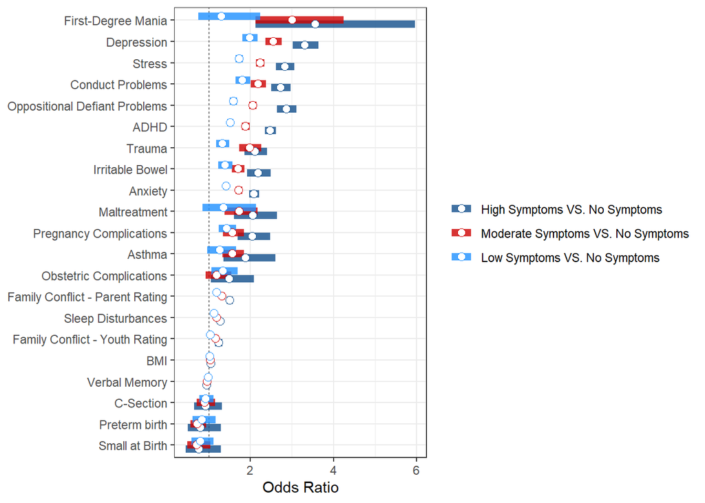

```r
# Plot Odds Ratio
riskfactors_wo_c %>%
ggplot(aes(x=OR,y=reorder(var,OR)))+
  geom_vline(xintercept=1,linetype='dashed',linewidth=0.1)+
    geom_errorbar(aes(xmin=lower_95,xmax=upper_95,color=class),width=0, linewidth=2.5,alpha=0.8,position=position_dodge(width=0.55))+
      geom_point(size=2.5,shape=21,fill="white",aes(color=class), position=position_dodge(width=0.55))+
         labs(x='Odds Ratio')+
            theme(axis.title.y = element_blank(),
              legend.title = element_blank())+
                scale_color_manual(values = c('1' = 'dodgerblue4', '2' = 'red3', '3' = 'dodgerblue1'),
                     labels = c('1' = "High Symptoms VS. No Symptoms",
                                '2' = "Moderate Symptoms VS. No Symptoms",
                                '3' = "Low Symptoms VS. No Symptoms"),
                       limits = c('1', '2', '3')) +  # Change the order of the legend)
                      scale_y_discrete(labels=c("SLEEP" = "Sleep Disturbances",  "IBS" = "Irritable Bowel", "ASTHMA" = "Asthma", "BMI" = "BMI", "PREG" = "Pregnancy Complications", "OBST" = "Obstetric Complications",  "PREMAT" = "Preterm birth", "SMALL" = "Small at Birth", "CSECT" = "C-Section", "DEPRESS" = "Depression", "ANX" = "Anxiety", "ADHD" = "ADHD", "OPPOSIT" = "Oppositional Defiant Problems", "CONDUCT" = "Conduct Problems",  "STRESS" = "Stress",  "RAVLT" = "Verbal Memory", "FES_P" = "Family Conflict - Parent Rating", "FES_Y" = "Family Conflict - Youth Rating",   "TRAUMA" = "Trauma", "MALTR" = "Maltreatment", "FIRST_D" = "First-Degree Mania"))
```

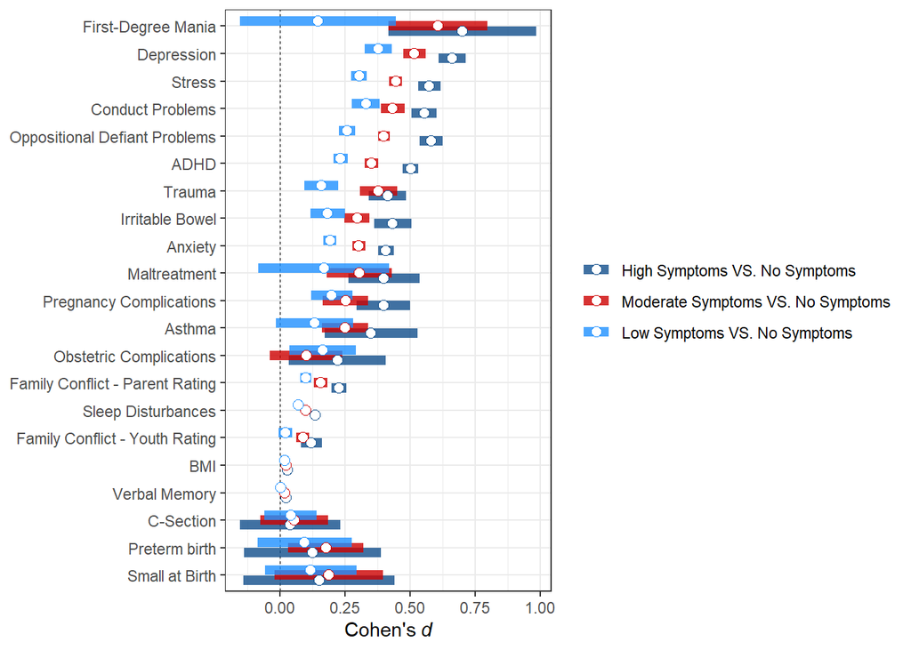

```r
#Plot absolute effect sizes (Cohen's d).
riskfactors_wo_c %>%
    mutate(lower_95_d=if_else(est_d<0,lower_95_d*-1,lower_95_d),
         upper_95_d=if_else(est_d<0,upper_95_d*-1,upper_95_d),
         est_d=if_else(est_d<0,est_d*-1,est_d)) %>%
  ggplot(aes(x=est_d,y=reorder(var,OR)))+
  geom_vline(xintercept=0,linetype='dashed',linewidth=0.1)+
  geom_errorbar(aes(xmin=lower_95_d,xmax=upper_95_d,color=class),width=0,
                linewidth=2.5,alpha=0.8,position=position_dodge(width=0.55))+
  geom_point(size=2.5,shape=21,fill="white",aes(color=class),
             position=position_dodge(width=0.55))+
  labs(x=expression("Cohen's"~italic(d)))+
  theme(axis.title.y = element_blank(),
        legend.title = element_blank())+
                scale_color_manual(values = c('1' = 'dodgerblue4', '2' = 'red3', '3' = 'dodgerblue1'),
                     labels = c('1' = "High Symptoms VS. No Symptoms",
                                '2' = "Moderate Symptoms VS. No Symptoms",
                                '3' = "Low Symptoms VS. No Symptoms"),
                       limits = c('1', '2', '3')) +  # Change the order of the legend)
                      scale_y_discrete(labels=c("SLEEP" = "Sleep Disturbances",  "IBS" = "Irritable Bowel", "ASTHMA" = "Asthma", "BMI" = "BMI", "PREG" = "Pregnancy Complications", "OBST" = "Obstetric Complications",  "PREMAT" = "Preterm birth", "SMALL" = "Small at Birth", "CSECT" = "C-Section", "DEPRESS" = "Depression", "ANX" = "Anxiety", "ADHD" = "ADHD", "OPPOSIT" = "Oppositional Defiant Problems", "CONDUCT" = "Conduct Problems",  "STRESS" = "Stress",  "RAVLT" = "Verbal Memory", "FES_P" = "Family Conflict - Parent Rating", "FES_Y" = "Family Conflict - Youth Rating",   "TRAUMA" = "Trauma", "MALTR" = "Maltreatment", "FIRST_D" = "First-Degree Mania"))
```

## Demographics Only

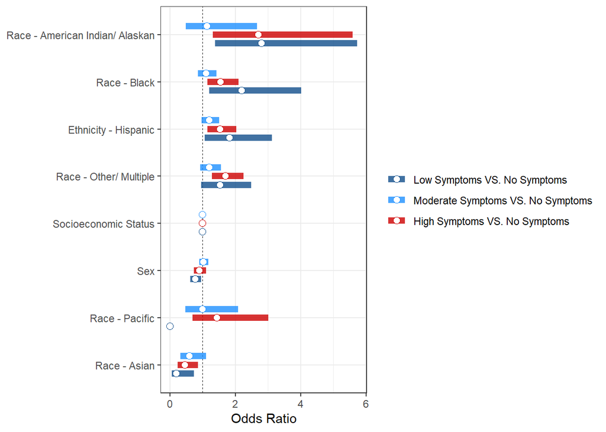

```r
# Plot Odds Ratio
covariates %>%
ggplot(aes(x=OR,y=reorder(var,OR)))+
  geom_vline(xintercept=1,linetype='dashed',linewidth=0.1)+
    geom_errorbar(aes(xmin=lower_95,xmax=upper_95,color=class),width=0, linewidth=2.5,alpha=0.8,position=position_dodge(width=0.55))+
      geom_point(size=2.5,shape=21,fill="white",aes(color=class), position=position_dodge(width=0.55))+
         labs(x='Odds Ratio')+
            theme(axis.title.y = element_blank(),
              legend.title = element_blank())+
                scale_color_manual(values = c('1' = 'dodgerblue4', '2' = 'red3', '3' = 'dodgerblue1'),
                     labels = c('1' = "Low Symptoms VS. No Symptoms",
                                '2' = "High Symptoms VS. No Symptoms",
                                '3' = "Moderate Symptoms VS. No Symptoms"),
                       limits = c('1', '3', '2')) +  # Change the order of the legend)
                      scale_y_discrete(labels=c("SEX" = "Sex", "RACE_B" = "Race - Black", "RACE_AI" = "Race - American Indian/ Alaskan", "RACE_P" = "Race - Pacific", "RACE_AS" = "Race - Asian", "RACE_O" = "Race - Other/ Multiple", "ETHN" = "Ethnicity - Hispanic", "INR" = "Socioeconomic Status"))
```

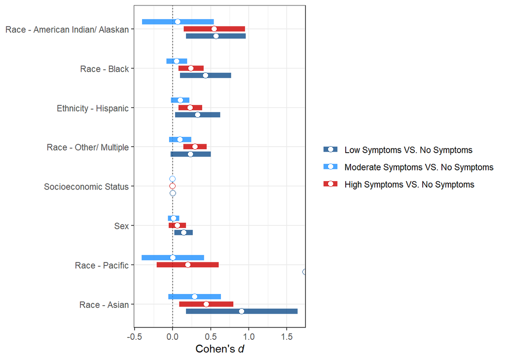

```r
#Plot absolute effect sizes (Cohen's d).
covariates %>%
    mutate(lower_95_d=if_else(est_d<0,lower_95_d*-1,lower_95_d),
         upper_95_d=if_else(est_d<0,upper_95_d*-1,upper_95_d),
         est_d=if_else(est_d<0,est_d*-1,est_d)) %>%
  ggplot(aes(x=est_d,y=reorder(var,OR)))+
  geom_vline(xintercept=0,linetype='dashed',linewidth=0.1)+
  geom_errorbar(aes(xmin=lower_95_d,xmax=upper_95_d,color=class),width=0,
                linewidth=2.5,alpha=0.8,position=position_dodge(width=0.55))+
  geom_point(size=2.5,shape=21,fill="white",aes(color=class),
             position=position_dodge(width=0.55))+
  labs(x=expression("Cohen's"~italic(d)))+
  theme(axis.title.y = element_blank(),
        legend.title = element_blank())+
                scale_color_manual(values = c('1' = 'dodgerblue4', '2' = 'red3', '3' = 'dodgerblue1'),
                     labels = c('1' = "Low Symptoms VS. No Symptoms",
                                '2' = "High Symptoms VS. No Symptoms",
                                '3' = "Moderate Symptoms VS. No Symptoms"),
                       limits = c('1', '3', '2')) +  # Change the order of the legend)
                      scale_y_discrete(labels=c("SEX" = "Sex", "RACE_B" = "Race - Black", "RACE_AI" = "Race - American Indian/ Alaskan", "RACE_P" = "Race - Pacific", "RACE_AS" = "Race - Asian", "RACE_O" = "Race - Other/ Multiple", "ETHN" = "Ethnicity - Hispanic", "INR" = "Socioeconomic Status"))
```

## Risk Factors with Covariates

```r
rm(list = ls())
load("E:/data/riskfactors_with_covariates_FINAL.rdata")
riskfactors_with_covariates_FINAL$class = as.factor(riskfactors_with_covariates_FINAL$class)
```

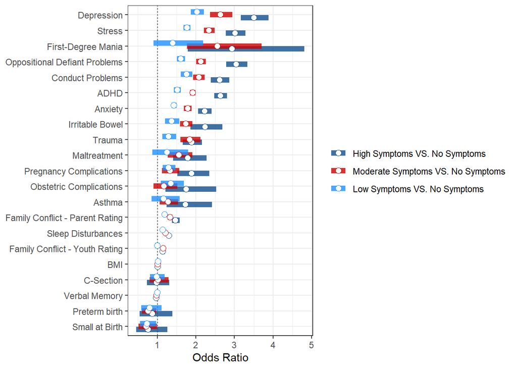

```r
# Plot Odds Ratio
riskfactors_with_covariates_FINAL %>%
ggplot(aes(x=OR,y=reorder(var,OR)))+
  geom_vline(xintercept=1,linetype='dashed',linewidth=0.1)+
    geom_errorbar(aes(xmin=lower_95,xmax=upper_95,color=class),width=0, linewidth=2.5,alpha=0.8,position=position_dodge(width=0.55))+
      geom_point(size=2.5,shape=21,fill="white",aes(color=class), position=position_dodge(width=0.55))+
         labs(x='Odds Ratio')+
            theme(axis.title.y = element_blank(),
              legend.title = element_blank())+
                scale_color_manual(values = c('1' = 'dodgerblue4', '2' = 'red3', '3' = 'dodgerblue1'),
                     labels = c('1' = "High Symptoms VS. No Symptoms",
                                '2' = "Moderate Symptoms VS. No Symptoms",
                                '3' = "Low Symptoms VS. No Symptoms"),
                       limits = c('1', '2', '3')) +  # Change the order of the legend)
                      scale_y_discrete(labels=c("SLEEP" = "Sleep Disturbances",  "IBS" = "Irritable Bowel", "ASTHMA" = "Asthma", "BMI" = "BMI", "PREG" = "Pregnancy Complications", "OBST" = "Obstetric Complications",  "PREMAT" = "Preterm birth", "SMALL" = "Small at Birth", "CSECT" = "C-Section", "DEPRESS" = "Depression", "ANX" = "Anxiety", "ADHD" = "ADHD", "OPPOSIT" = "Oppositional Defiant Problems", "CONDUCT" = "Conduct Problems",  "STRESS" = "Stress",  "RAVLT" = "Verbal Memory", "FES_P" = "Family Conflict - Parent Rating", "FES_Y" = "Family Conflict - Youth Rating",   "TRAUMA" = "Trauma", "MALTR" = "Maltreatment", "FIRST_D" = "First-Degree Mania"))
```

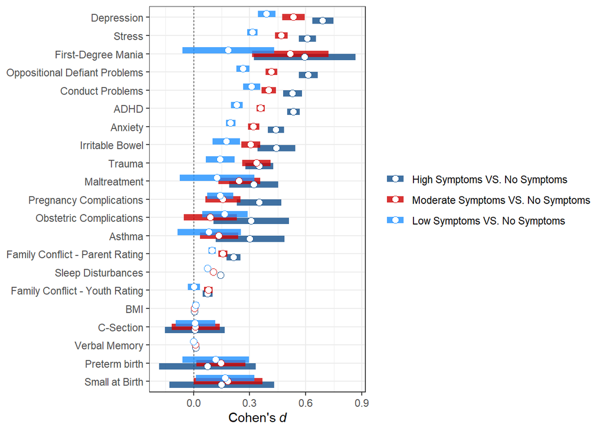

```r
#Plot absolute effect sizes (Cohen's d).
riskfactors_with_covariates_FINAL %>%
    mutate(lower_95_d=if_else(est_d<0,lower_95_d*-1,lower_95_d),
         upper_95_d=if_else(est_d<0,upper_95_d*-1,upper_95_d),
         est_d=if_else(est_d<0,est_d*-1,est_d)) %>%
  ggplot(aes(x=est_d,y=reorder(var,OR)))+
  geom_vline(xintercept=0,linetype='dashed',linewidth=0.1)+
  geom_errorbar(aes(xmin=lower_95_d,xmax=upper_95_d,color=class),width=0,
                linewidth=2.5,alpha=0.8,position=position_dodge(width=0.55))+
  geom_point(size=2.5,shape=21,fill="white",aes(color=class),
             position=position_dodge(width=0.55))+
  labs(x=expression("Cohen's"~italic(d)))+
  theme(axis.title.y = element_blank(),
        legend.title = element_blank())+
                scale_color_manual(values = c('1' = 'dodgerblue4', '2' = 'red3', '3' = 'dodgerblue1'),
                     labels = c('1' = "High Symptoms VS. No Symptoms",
                                '2' = "Moderate Symptoms VS. No Symptoms",
                                '3' = "Low Symptoms VS. No Symptoms"),
                       limits = c('1', '2', '3')) +  # Change the order of the legend)
                      scale_y_discrete(labels=c("SLEEP" = "Sleep Disturbances",  "IBS" = "Irritable Bowel", "ASTHMA" = "Asthma", "BMI" = "BMI", "PREG" = "Pregnancy Complications", "OBST" = "Obstetric Complications",  "PREMAT" = "Preterm birth", "SMALL" = "Small at Birth", "CSECT" = "C-Section", "DEPRESS" = "Depression", "ANX" = "Anxiety", "ADHD" = "ADHD", "OPPOSIT" = "Oppositional Defiant Problems", "CONDUCT" = "Conduct Problems",  "STRESS" = "Stress",  "RAVLT" = "Verbal Memory", "FES_P" = "Family Conflict - Parent Rating", "FES_Y" = "Family Conflict - Youth Rating",   "TRAUMA" = "Trauma", "MALTR" = "Maltreatment", "FIRST_D" = "First-Degree Mania"))
```

## Plot Sleep Subscales

```r
rm(list = ls())
load("E:/data/riskfactors_sleep_FINAL.rdata")
```

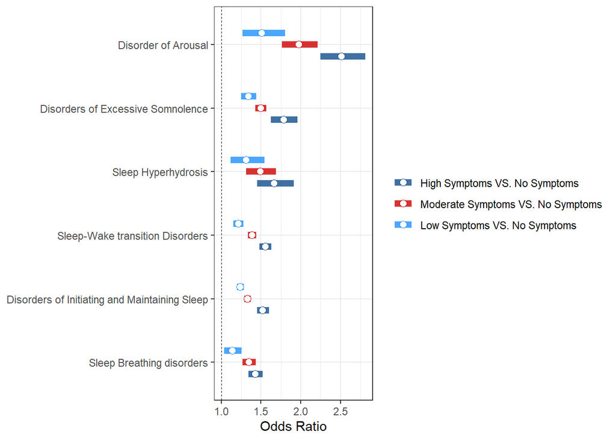

```r
# Plot Odds Ratio
riskfactors_sleep_FINAL %>%
ggplot(aes(x=OR,y=reorder(var,OR)))+
  geom_vline(xintercept=1,linetype='dashed',linewidth=0.1)+
    geom_errorbar(aes(xmin=lower_95,xmax=upper_95,color=class),width=0, linewidth=2.5,alpha=0.8,position=position_dodge(width=0.55))+
      geom_point(size=2.5,shape=21,fill="white",aes(color=class), position=position_dodge(width=0.55))+
         labs(x='Odds Ratio')+
            theme(axis.title.y = element_blank(),
              legend.title = element_blank())+
                scale_color_manual(values = c('1' = 'dodgerblue4', '2' = 'red3', '3' = 'dodgerblue1'),
                     labels = c('1' = "High Symptoms VS. No Symptoms",
                                '2' = "Moderate Symptoms VS. No Symptoms",
                                '3' = "Low Symptoms VS. No Symptoms"),
                       limits = c('1', '2', '3')) +  # Change the order of the legend)
                      scale_y_discrete(labels=c("DIMS" = "Disorders of Initiating and Maintaining Sleep", "SBD" = "Sleep Breathing disorders", "DA" = "Disorder of Arousal", "SWTD" = "Sleep-Wake transition Disorders", "DOES" = "Disorders of Excessive Somnolence", "SHY" = "Sleep Hyperhydrosis"))
```

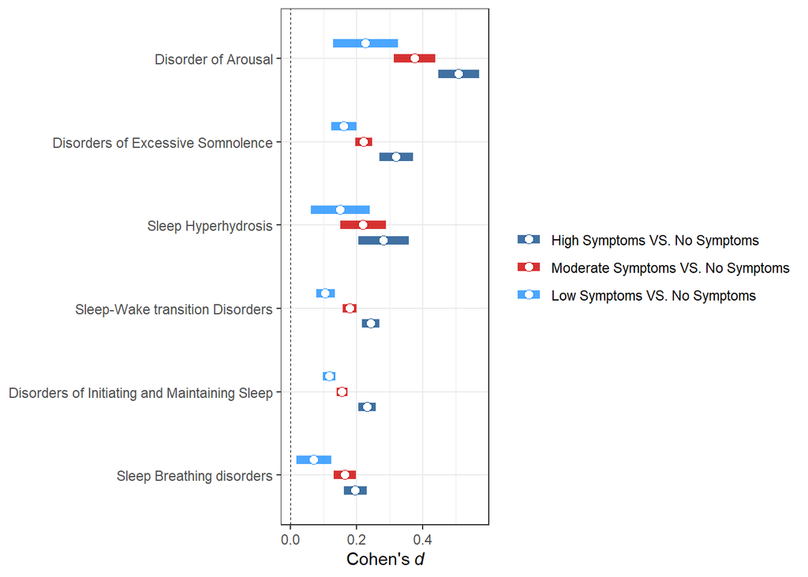

```r
#Plot absolute effect sizes (Cohen's d).
riskfactors_sleep_FINAL %>%
    mutate(lower_95_d=if_else(est_d<0,lower_95_d*-1,lower_95_d),
         upper_95_d=if_else(est_d<0,upper_95_d*-1,upper_95_d),
         est_d=if_else(est_d<0,est_d*-1,est_d)) %>%
  ggplot(aes(x=est_d,y=reorder(var,OR)))+
  geom_vline(xintercept=0,linetype='dashed',linewidth=0.1)+
  geom_errorbar(aes(xmin=lower_95_d,xmax=upper_95_d,color=class),width=0,
                linewidth=2.5,alpha=0.8,position=position_dodge(width=0.55))+
  geom_point(size=2.5,shape=21,fill="white",aes(color=class),
             position=position_dodge(width=0.55))+
  labs(x=expression("Cohen's"~italic(d)))+
  theme(axis.title.y = element_blank(),
        legend.title = element_blank())+
                scale_color_manual(values = c('1' = 'dodgerblue4', '2' = 'red3', '3' = 'dodgerblue1'),
                     labels = c('1' = "High Symptoms VS. No Symptoms",
                                '2' = "Moderate Symptoms VS. No Symptoms",
                                '3' = "Low Symptoms VS. No Symptoms"),
                       limits = c('1', '2', '3')) +  # Change the order of the legend)
                      scale_y_discrete(labels=c("DIMS" = "Disorders of Initiating and Maintaining Sleep", "SBD" = "Sleep Breathing disorders", "DA" = "Disorder of Arousal", "SWTD" = "Sleep-Wake transition Disorders", "DOES" = "Disorders of Excessive Somnolence", "SHY" = "Sleep Hyperhydrosis"))
```

## Correlation Plot

This code computes and visualizes the correlation matrix for several psychological traits measured in the dataset (Depression, Anxiety, ADHD, Conduct Problems, Oppositional Behavior, and Stress). It helps assess how strongly these variables are related to each other.

If highly related traits (e.g., Depression & Anxiety) are strongly correlated, it confirms that the measures are capturing similar constructs. However, if correlations are too high (r > 0.9), it can indicate redundancy in the data. This is problematic in regression models because it makes it difficult to determine the unique effect of each variable. In this case, it might be necessary to adjust the analysis to avoid redundancy.

CBCL = Depression, Anxiety, Adhd, Conduct, Opposition, Stress

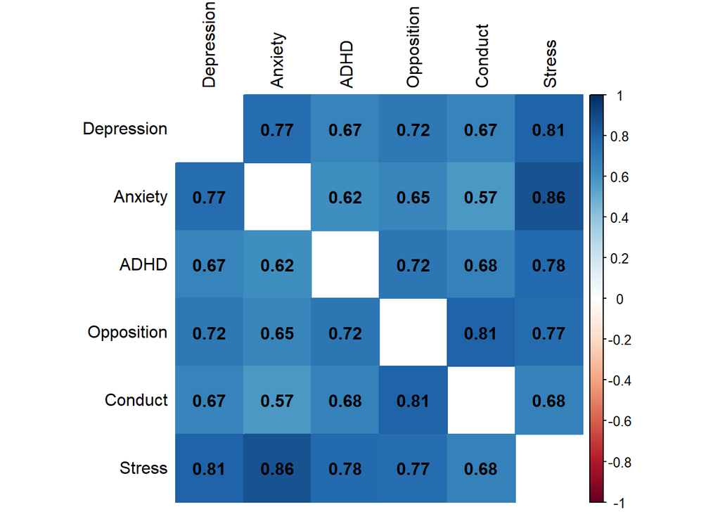

```r
library(corrplot)
rm(list = ls())

#load("E:/data/riskfactors_without_covariates.rdata")
#load("E:/data/riskfactors_with_covariates.rdata")
#"G:\Geteilte Ablagen\NeRD_lab\research_projects\ABCD_mania\code\MPLUS\new_data_predictors.csv"

setwd("E:/code/MPLUS")
data <- read.csv("new_data_predictors.csv", header = TRUE, stringsAsFactors = FALSE)

# Select Variables
# Define a vector of columns you want to select
columns_to_select <- c("cbcl_scr_dsm5_depress_r_0",
                       "cbcl_scr_dsm5_anxdisord_r_0",
                       "cbcl_scr_dsm5_adhd_r_0",
                       "cbcl_scr_dsm5_opposit_r_0",
                       "cbcl_scr_dsm5_conduct_r_0",
                       "cbcl_scr_07_stress_r_0")

# Select columns using the vector
data <- data %>%
  select(all_of(columns_to_select))

# Create correlation matrix
cor_matrix <-cor(data,use='pairwise.complete.obs')
# Rename the column and row in the correlation matrix
colnames(cor_matrix)[colnames(cor_matrix) == "cbcl_scr_dsm5_depress_r_0"] <- "Depression"
rownames(cor_matrix)[rownames(cor_matrix) == "cbcl_scr_dsm5_depress_r_0"] <- "Depression"
colnames(cor_matrix)[colnames(cor_matrix) == "cbcl_scr_dsm5_anxdisord_r_0"] <- "Anxiety"
rownames(cor_matrix)[rownames(cor_matrix) == "cbcl_scr_dsm5_anxdisord_r_0"] <- "Anxiety"
colnames(cor_matrix)[colnames(cor_matrix) == "cbcl_scr_dsm5_adhd_r_0"] <- "ADHD"
rownames(cor_matrix)[rownames(cor_matrix) == "cbcl_scr_dsm5_adhd_r_0"] <- "ADHD"
colnames(cor_matrix)[colnames(cor_matrix) == "cbcl_scr_dsm5_opposit_r_0"] <- "Opposition"
rownames(cor_matrix)[rownames(cor_matrix) == "cbcl_scr_dsm5_opposit_r_0"] <- "Opposition"
colnames(cor_matrix)[colnames(cor_matrix) == "cbcl_scr_dsm5_conduct_r_0"] <- "Conduct"
rownames(cor_matrix)[rownames(cor_matrix) == "cbcl_scr_dsm5_conduct_r_0"] <- "Conduct"
colnames(cor_matrix)[colnames(cor_matrix) == "cbcl_scr_07_stress_r_0"] <- "Stress"
rownames(cor_matrix)[rownames(cor_matrix) == "cbcl_scr_07_stress_r_0"] <- "Stress"


# get p-values
testRes = cor.mtest(data, conf.level = 0.95)

#basic plot.
corrplot(cor_matrix,method='color',
         p.mat = testRes$p,
         diag=F,
         tl.col = 'black',
         addCoef.col = 'black')
```

Interpretation: Depression, Anxiety, ADHD, and Conduct Problems frequently coexist in clinical populations. Higher stress levels are expected to correlate with all other symptoms. This pattern reflects reality rather than redundancy.  
Correlations do not exceed 0.90, meaning each variable still provides unique information.